# Quant Trading Strategies

"Quant" is the application of the scientific method to investing. Recall the scientific method - observing a phenomena, developing a hypothesis about it, then designing & executing an experiment to confirm or disprove your hypothesis. Of course, we don't conduct experiments, we just gather the appropriate data. The key is to have some hard evidence backing up your idea.

Here, I'll go through an example where I try to develop a strategy which uses the phenomena of "momentum".

# Momentum

"Momentum" is a phenomenon oberved across a diverse range of assets, where the assets that previously went up in price will continue to do so. It is an extremely broad idea as well - implementations can take various forms, a few examples of which are given below:

- trend trading on a single name
- momentum as one factor within a bigger factor model
- cross-sectional trading using momentum to rank

Momentum is already a popular strategy - here's how a momentum ETF (MTUM) outperforms SPY over 5 years (2012-2017):

[figure not shown]

Clearly we should check it out and try to come up with our own version. There are a few of steps that we have to do, to go from the broad abstract concept of "momentum" to a usable strategy:

1. pick a universe to trade on
2. pick a type of trade
   1. time series vs. cross-sectional
3. determine how we measure momentum
   1. define the timeframe
4. get the data
5. check if *our definition* of momentum (determined in step 3) has a statistical edge
6. if yes to 5, then write a backtest, check risk stats, and correlate to our other strategies

Let's begin. I'll use a universe of the S&P over the past 20y, for ease of data collection.

###### Getting Data

I want to create a specific data format for this project: a CSV file with dates as rows and tickers as columns, with the corresponding prices as the values.  
Then, we can use different CSVs to examine different universes. Pandas is great as it handles all the NAs for us, so we don't have to build any missing-value handlers.

```python
import pandas as pd
import numpy as np

price_data = pd.read_csv("20yr S&P Data.csv", index_col=0, parse_dates=True)

# calculate returns from prices
returns_data = price_data.diff() / price_data.shift(1)
```

So, the `returns_data` dataframe has the returns for the assets given in your CSV.

###### Functions

Next, we need to make our scoring functions. We'll have to make the following:

- past momentum score function
- forward returns function

Then, we can regress future returns on past momentum and see if momentum has any predictive power.

In the prevailing literature on momentum, the academics use an annoyingly simple measure of momentum - the return over the past 12m. Here, I try to use a different measure, which accounts for volatility (smoothness) of the return series as well.

My choice of a metric to measure momentum involves another regression. Here, I regress the stock's returns on a fake "perfect momentum" stream of returns (a bunch of 1% gains) and check the R^2. If the R^2 is .9, for example, then the stock's returns are 90% explained by a constant 1% gain every day. In addition, the actual value of 1% doesn't matter here - in our definition, "perfect momentum" should only be a *constant* positive return.

Here's what I mean by "perfect":

[figure not shown]

Even though Arrowhead stock is rallying pretty hard and would be considered very-high-momentum (I found it by screening for the highest-returning stocks), it's definitely not perfect from a momentum perspective.

We can sort all the stocks on our momentum score, because the highest R^2 values indicate the stocks who differ the least from our "perfect momentum stock".

```python
from sklearn import linear_model

def cumulate(series):
    series = series + 1
    return series.cumprod()

def momentum_score(ticker, date, lookback):

    # get the index of the date arg
    date_index = returns_data.index.get_loc(date)

    # get cumulative returns as a series
    returns_series = cumulate(returns_data[ticker].iloc[(date_index - lookback):date_index]).dropna()

    if len(returns_series) == 0:
        return "na";

    n = len(returns_series)

    # make an array of 1bp returns
    perfect_returns = cumulate(pd.DataFrame(np.ones(n)/10000))

    # fit reg, predictor = perfect returns, response = stock returns
    regr = linear_model.LinearRegression()
    regr.fit(perfect_returns, returns_series)

    # return signed R^2 value
    return regr.score(perfect_returns, returns_series) * np.sign(regr.coef_[0]);

import datetime as dt
latest_date = dt.date(2017, 8, 30)
current_scores = pd.DataFrame({"Ticker":price_data.columns, "Scores":[momentum_score(t, latest_date, 252) for t in price_data.columns]}).sort_values("Scores")
print(current_scores.tail())
print("---")
print(current_scores.iloc[450])
```

```
       Scores Ticker
89   0.961800    ALL
124  0.962959     RE
295  0.966343    RCL
109  0.966816    PGR
191  0.978171  CCL.U
---
Scores    0.879844
Ticker         GLW
Name: 58, dtype: object
```

So the 5th-highest scorer is ALL (Allstate) and the 50th-highest is GLW (Corning). Let's confirm that they look like momentum stocks, and that ALL looks a little better than GLW:

[figure not shown]

```python
def forward_return(ticker, date, lookforward, df = price_data): # added a df argument so that we can use SPY_data later
    date_index = df.index.get_loc(date)
    p0 = df.loc[date].loc[ticker]
    p1 = df.iloc[date_index + lookforward].loc[ticker]
    if np.isnan(p0) or np.isnan(p1):
        return "na";
    return p1 / p0;
```

###### Hypothesis Testing

This step is where we use our scoring functions to check if a statistical relationship exists between our proprietary momentum score and the forward returns of the stock. There are two parameters we can manipulate: lookback & lookforward. We want to find values for the 2 parameters which have a few properties:

- makes intuitive sense (lookback of 1 day and lookforward of 2 years does NOT make sense)
- significance isn't very sensitive to changes in parameters

There is no guarantee that we'll be able to find parameters which show a significant relationship! If there isn't any significance, then we don't have any basis to try and build a strategy out of it.

I'll also make a function for this step. The function has the two parameters as inputs, and returns a dataframe which is ready to be checked for significance.

```python
def hypothesis_testing_dataframe(lookback, lookforward, *datearg):
    df = pd.DataFrame()
    SPY = pd.DataFrame()
    tickers = price_data.columns

    #  if no date(s) given, use a random date
    if len(datearg) == 0:
        sample_dates = pd.Series(price_data.iloc[lookback:(len(price_data)-lookforward)].index).sample(1)
    else:
        sample_dates = datearg

    i = 1
    for d in sample_dates:
        for t in tickers:

            score = momentum_score(t, d, lookback)
            response = forward_return(t, d, lookforward)
            i += 1

                # record the calculations in df
            if score != "na" and response != "na":
                row = pd.Series({"Ticker":t, "Date":d, "Score":score, "Return":response})
                df = df.append(row, ignore_index=True)

        SPY_row = pd.Series({"Date":d, "Return":forward_return("SPY", d, lookforward, SPY_data)})
        SPY = SPY.append(SPY_row, ignore_index=True)

    return [df, SPY];
```

The logic is that we'd want to see if the top scorers have a different mean return from the S&P as a whole. I will use a size of 250 stocks for the top-scoring group (i.e. the best half of S&P stocks). Then, we can compare those 250 stocks to a bucket of 250 shares of SPY. If our 250 stocks have a significantly greater mean forward return than SPY, then we have a strategy!

One useful fact here for our implementation is the denominator of the t-test. The formula to get the t-statistic is as follows:

[figure not shown]

In the denominator, notice that the sample standard deviation used to standardize is simply the *average* of the two groups' standard deviations. If we have 250 shares of SPY in one of our groups, then that group's *s* will be zero and the denominator will be the *SE* of the group with the 250 momentum stocks. This means that we can, in fact, use 250 shares of SPY as the comparison in the t-test; the fact that it will be 250 of the same return only affects the results as far as the t-statistic's standard error will be approximately half of what it should be, and implementing this is quite easy given SPY returns. So the trade-off for using a t-test here is that we should look for about twice the significance.

```python
from scipy.stats import ttest_ind
SPY_data = pd.read_csv("SPY Data.csv", index_col=0, parse_dates=True)

def check_significance(df_list, bucket_size):

    # recall df_list[0] are the calculations, df_list[1] are the SPY numbers to benchmark too
    scores_df = df_list[0]

    # sort df on momentum score
    sorted = scores_df.sort_values("Score")

    best = sorted.iloc[(len(sorted) - bucket_size):len(sorted)]
    SPY_returns = np.repeat(df_list[1].iloc[0]["Return"], bucket_size)

    # res is a t-test for the difference in means between two groups
    res = ttest_ind(SPY_returns, best["Return"])
    return(res.pvalue)
```

Now, I will run a few samples using a lookback of ~3 years and a lookforward of ~1 year, and check for significance. I am using these values because they are backed up by research in a book I read: *Quantitative Momentum*. However, if you are running this on your own I encourage you to write a loop and test different parameter values to see if you can get even better significance.

```python
lookback = 753
lookforward = 253
for j in range(0,10):
    results = hypothesis_testing_dataframe(lookback, lookforward) # no date arg => use a random date
    print(check_significance(results, 250))
```

```
    0.000496921127235
    4.43173954379e-05
    0.95334774792
    1.17236553406e-07
    4.2956926137e-08
    0.24062113856
    6.2548080498e-07
    1.93408857042e-05
    8.67513194428e-06
    2.62832649091e-07
```

Success! For most of these random dates, the 250 best momentum stocks have a forward return which is significantly different from SPY.

Since the significance varies, depending on the date that you are checking, we should check what dates are good dates and what dates are bad dates.

The next code block is a loop which creates two arrays: dates & the p-values for those dates.

```python
import matplotlib.pyplot as plt
import matplotlib.dates as mdates
import datetime as dt
all_dates = pd.date_range(dt.date(2000,8,28), dt.date(2016,8,25))
included_dates = []
t_stats = []
for date in all_dates:
    # check if date exists in df
    if date in price_data.index:
        x = hypothesis_testing_dataframe(753, 253, date)
        p_val = check_significance(x, 30)
        included_dates.append(date)
        t_stats.append(p_val)
print("done") # because it takes a while to run completely
```

```
done
```

Using the two arrays `included_dates` and `t_stats`, we can make a chart of when our momentum factor outperforms, and when it doesn't. I'll also include SPY - maybe it will tell us something about when specifically momentum generates alpha.

(i.e. the shaded days are "good days to start momentum" from a statistical perspective)

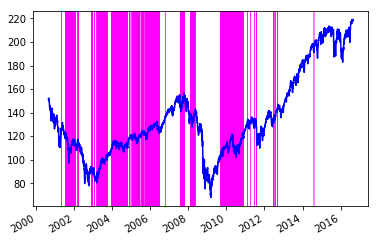

```python
t = included_dates
y = SPY_data.loc[included_dates]

fig, ax = plt.subplots()
ax.plot_date(t, y, 'b-')
for i in range(0, len(t_stats)):
    if t_stats[i] < .005:
        ax.axvspan(*mdates.date2num([included_dates[i], included_dates[i]]), color='magenta', alpha=0.5)  # try lw?
fig.autofmt_xdate()
plt.show()
```

For trading purposes, I would stop here, as there isn't a statisical justification for this strategy nowadays. However, there's one thing I'd like to check. If we backtest our strategy from 2003 to 2006, it should perform much better than if we backtest from 2013 to 2016. Let's write a backtest and check the performance statistics.

###### Strategy Performance

Following is the backtest function:

```python
import datetime as dt
def backtest(date0, date1, prices = price_data, lb=753, lf=253, buckets=250):
    all_dates = pd.date_range(date0, date1)
    included_dates = []
    returns = []
    # for date in all_dates:
    for ddd in range(0, len(all_dates), 21):
        date_ret = 0
        if all_dates[ddd] in prices.index:

            # print(date)
            # create a list of relevant dates for this specific date
            date=all_dates[ddd]

            date_index = prices.index.get_loc(date)

            for i in range((date_index-lf), date_index, 125):

                sub_ret = 0

                # this if makes sure the first few periods of backtest don't
                # rely on data outside the range you are testing on
                if prices.index[i] in all_dates:

                    # use prev function to do all the scoring
                    x = hypothesis_testing_dataframe(lb, lf, prices.index[i])

                    # get list of winners
                    scores_df = x[0]
                    sorted = scores_df.sort_values("Score")
                    best = sorted.iloc[(len(sorted) - buckets):len(sorted)]
                    for ticker in best["Ticker"]:
                        r = (forward_return(ticker, prices.index[i], (date_index-i)) - 1) / buckets
                        sub_ret += r

                # use sub_ret / lf if trading every day
                # date_ret += sub_ret / lf

                # use sub_ret / 2 if trading every 6 months, per jupyter notebook example
                date_ret += sub_ret / 2

            included_dates.append(date)
            returns.append(date_ret)

    return pd.DataFrame({"Date":included_dates, "Return":returns})

d0 = dt.date(2003,1,1)
d1 = dt.date(2006,1,1)
results_2000s = backtest(d0, d1)
print("finished 2000s")

d0 = dt.date(2013,1,1)
d1 = dt.date(2016,1,1)
results_2010s = backtest(d0, d1)
print("finished 2010s")
```

```
finished 2000s
finished 2010s
```

Then, let's compare the performance:

```python
print("Sharpe in 2000s:")
print(np.mean(results_2000s["Return"])/np.std(results_2000s["Return"]))
print("")
print("Sharpe in 2010s:")
print(np.mean(results_2010s["Return"])/np.std(results_2010s["Return"]))
```

```
Sharpe in 2000s:
1.7374601138904058

Sharpe in 2010s:
1.3584234728393303
```

So, we've confirmed our hypothesis that the performance of the strategy degrades over time. While we didn't get a tradable strategy from this research, we did at least confirm our statistical results with the backtest - and now we have all this code to use going forward. :)